# Lab 08 — Model Selection and Validation

EAES 480 — Modern Statistics in Earth & Environmental Science

April 06, 2026

# Overview

This lab extends your linear modeling work from **fitting and interpreting regression models** to **comparing models**.

In Part I, you will evaluate model fit using:

- **sum of squares**
- **R-squared**
- **MSE**
- **RMSE**
- and **residual diagnostics**

You will work with the **US-AMS simplified AmeriFlux dataset** again and choose your own response and predictor variables.

Part II will later extend this work to **train-test validation splits**.

# Learning goals

By the end of this lab, you should be able to:

- Fit and compare multiple linear regression models
- Use `tidy()`, `glance()`, and `augment()` to summarize models
- Compute **SST**, **SSE**, and **R-squared**
- Compute **MSE** and **RMSE**
- Compare models using both statistical summaries and plots
- Explain why model selection requires more than one metric
- Produce a fully reproducible R Markdown analysis

# Data

## Load and inspect

```r
# GOAL: Read the dataset and keep 2023 observations.

df <- read_csv("data/us-ams-simple_V2.csv", na = c("-9999")) %>%
  clean_names() %>%
  filter(year_local == 2023)

glimpse(df)
```

```
## Rows: 16,973
## Columns: 14
## $ year_local <dbl> 2023, 2023, 2023, 2023, 2023, 2023, 2023, 2023, 2023, 2023,…
## $ doy        <dbl> 1.0000, 1.0208, 1.0416, 1.0624, 1.0833, 1.1041, 1.1249, 1.1…
## $ daytime    <dbl> 0, 0, 0, 0, 0, 0, 0, 0, NA, NA, 0, 0, 0, 0, 0, 0, 1, 1, 1, …
## $ fc         <dbl> 1.4444700, 1.0018700, 1.7665700, 0.4639850, 0.8243290, 0.64…
## $ le         <dbl> -2.975490, -1.814240, -5.101540, -4.854642, -2.419090, -10.…
## $ ta         <dbl> 7.433350, 7.783740, 8.273390, 8.702240, 8.896600, 8.567610,…
## $ reco       <dbl> 1.291612, 1.312279, 1.341193, 1.366625, 1.378268, 1.359013,…
## $ gpp        <dbl> -0.1528577, 0.3104090, -0.4253767, 0.9026402, 0.5539394, 0.…
## $ swc        <dbl> 36.13111, 36.11948, 36.11560, 36.11172, 36.11172, 36.10008,…
## $ ts         <dbl> 2.50, 2.50, 2.50, 2.50, 2.50, 2.50, 2.50, 2.50, 2.50, 2.50,…
## $ rh         <dbl> 56.3240, 56.0741, 56.0960, 56.2822, 57.5869, 60.5177, 27.87…
## $ ws         <dbl> 1.52704, 1.57042, 1.24922, 1.70643, 2.45591, 2.22375, 1.793…
## $ p          <dbl> 0.0, 0.0, NA, 0.0, NA, 0.8, NA, 2.0, NA, 0.0, NA, 0.0, NA, …
## $ sw_in      <dbl> 5.1, 0.0, NA, NA, NA, NA, NA, NA, NA, NA, NA, NA, NA, NA, N…
```

## Derive time columns if needed

```r
# GOAL: Create date / month columns if they do not already exist.

df <- df %>%
  mutate(
    date = as.Date(floor(doy) - 1, origin = paste0(year_local, "-01-01")),
    month = month(date, label = TRUE, abbr = TRUE)
  )
```

# Part I — Model selection and assessment

## 1) Choose a response variable and candidate predictors

Pick: - **one numeric response variable** - **two candidate predictor variables**

Possible examples: - response: `le`, `fc`, `gpp` - predictors: `ta`, `swc`, `vpd`, `rg`

```r
response_var <- "le"
pred1 <- "ta"
pred2 <- "rh"

# CHECK: do these variables exist?
c(response_var, pred1, pred2) %in% names(df)
```

```
## [1] TRUE TRUE TRUE
```

> Which variables did you choose, and why do you think they may be related? I chose latent heat turbulent flux (le), air temperature (ta) and relative humidity (rh). I think they may be related because le represents energy exchange and water vapor.

## 2) Create a clean analysis dataset

Keep only rows with non-missing values for your chosen variables.

```r
# GOAL: Create an analysis data frame using only complete cases.

df_mod <- df %>%
  select(response_var, pred1, pred2) %>%
  drop_na()

glimpse(df_mod)
```

```
## Rows: 15,851
## Columns: 3
## $ le <dbl> -2.975490, -1.814240, -5.101540, -4.854642, -2.419090, -10.083700, …
## $ ta <dbl> 7.43335, 7.78374, 8.27339, 8.70224, 8.89660, 8.56761, 8.51371, 10.6…
## $ rh <dbl> 56.3240, 56.0741, 56.0960, 56.2822, 57.5869, 60.5177, 27.8732, 23.6…
```

## 3) Fit three models

Fit: - **Model 1:** response ~ pred1 - **Model 2:** response ~ pred2 - **Model 3:** response ~ pred1 + pred2

```r
m1 <- lm(df_mod[[response_var]] ~ df_mod[[pred1]], data = df_mod)
m2 <- lm(df_mod[[response_var]] ~ df_mod[[pred2]], data = df_mod)
m3 <- lm(df_mod[[response_var]] ~ df_mod[[pred1]] + df_mod[[pred2]], data = df_mod)
```

## 4) View coefficients with `tidy()`

```r
tidy(m1)
```

| term | estimate | std.error | statistic | p.value |
| --- | --- | --- | --- | --- |
| (Intercept) | -2.684189 | 0.82113289 | -3.268884 | 0.001082025 |
| df_mod[[pred1]] | 4.712418 | 0.04882263 | 96.521176 | 0.000000000 |

```r
tidy(m2)
```

| term | estimate | std.error | statistic | p.value |
| --- | --- | --- | --- | --- |
| (Intercept) | 133.95106 | 2.04476668 | 65.50922 | 0.000000e+00 |
| df_mod[[pred2]] | -1.37085 | 0.03615705 | -37.91376 | 3.598119e-301 |

```r
tidy(m3)
```

| term | estimate | std.error | statistic | p.value |
| --- | --- | --- | --- | --- |
| (Intercept) | 48.9629686 | 1.88691365 | 25.94871 | 2.014214e-145 |
| df_mod[[pred1]] | 4.4586301 | 0.04821388 | 92.47607 | 0.000000e+00 |
| df_mod[[pred2]] | -0.8940013 | 0.02959345 | -30.20944 | 5.735187e-195 |

> Which coefficients are positive? Which are negative? Do they make scientific sense? Model 1 is positive and Model 2 is negative. They made scientific sense because higher temperatures generally drive more evapotranspiration (more le), while higher humidity reduces the atmospheric demand for moisture (less le).

## 5) Visualize at least two one-predictor models

Make scatterplots with fitted linear trends for Model 1 and Model 2.

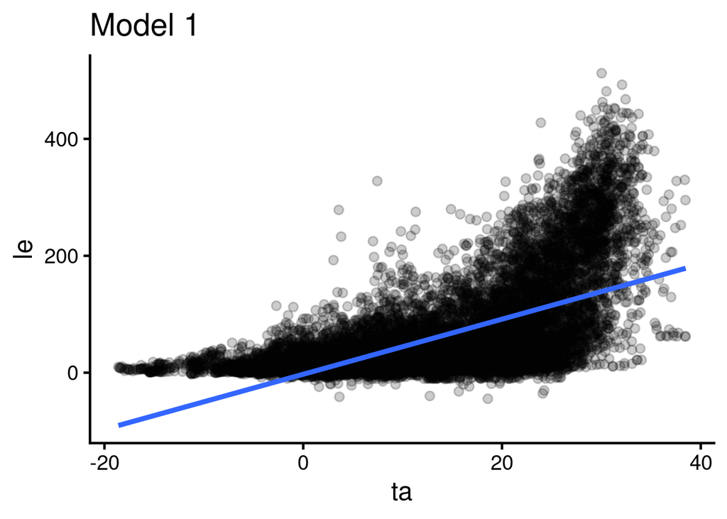

```r
ggplot(df_mod, aes(x = .data[[pred1]], y = .data[[response_var]])) +
  geom_point(alpha = 0.2) +
  geom_smooth(method = "lm", se = FALSE) +
  theme_classic(base_size = 18) +
  labs(
    x = pred1,
    y = response_var,
    title = "Model 1"
  )
```

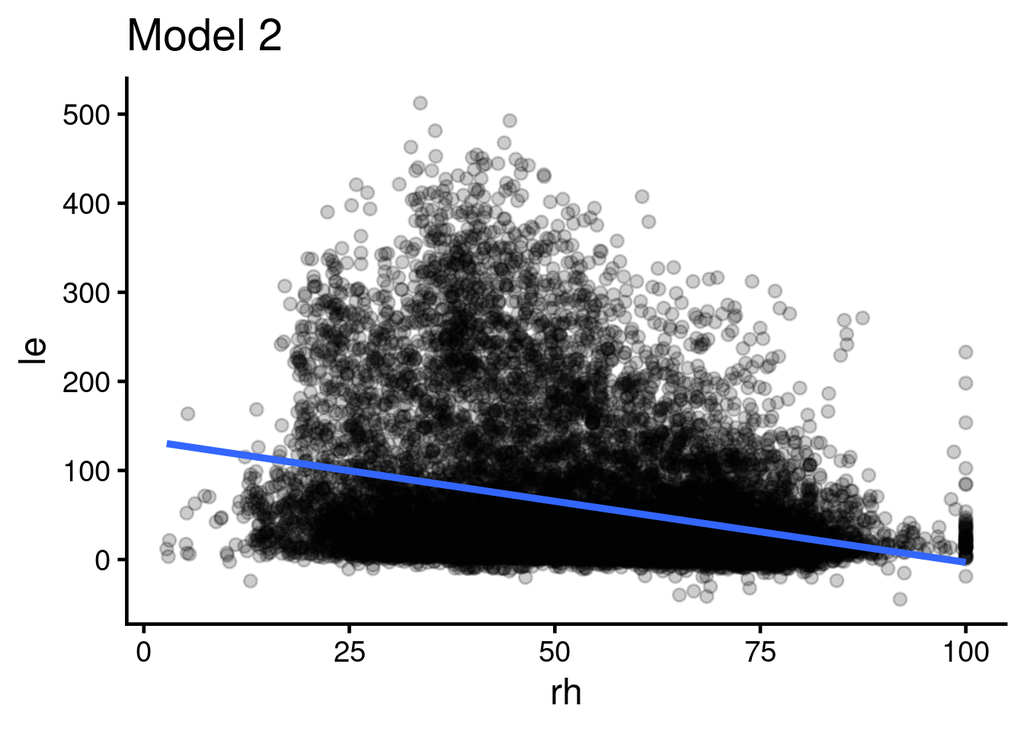

```r
ggplot(df_mod, aes(x = .data[[pred2]], y = .data[[response_var]])) +
  geom_point(alpha = 0.2) +
  geom_smooth(method = "lm", se = FALSE) +
  theme_classic(base_size = 18) +
  labs(
    x = pred2,
    y = response_var,
    title = "Model 2"
  )
```

> Visually, which model seems stronger? Why? Model 1 seems stronger than model 2 because is less fuzzy.

## 6) Get fitted values and residuals with `augment()`

```r
aug_m1 <- augment(m1)
aug_m2 <- augment(m2)
aug_m3 <- augment(m3)

aug_m1 %>% select(.fitted, .resid) %>% head()
```

| .fitted | .resid |
| --- | --- |
| 32.34486 | -35.32035 |
| 33.99605 | -35.81029 |
| 36.30348 | -41.40502 |
| 38.32440 | -43.17904 |
| 39.24031 | -41.65940 |
| 37.68997 | -47.77367 |

## 7) Compute sum of squares manually for Model 1

Recall:

- SST = total sum of squares
- SSE = sum of squared errors
- SSR = regression sum of squares

And:

$SST = SSR + SSE$

```r
y <- df_mod[[response_var]]
ybar <- mean(y)

sst <- sum((y - ybar)^2)
sse_m1 <- sum(aug_m1$.resid^2)
ssr_m1 <- sst - sse_m1

tibble(
  sst = sst,
  sse_m1 = sse_m1,
  ssr_m1 = ssr_m1
)
```

| sst | sse_m1 | ssr_m1 |
| --- | --- | --- |
| 101113554 | 63680796 | 37432758 |

## 8) Compute R-squared manually for Model 1

Use:

$R^2 = 1 - SSE / SST$

```r
r2_m1_manual <- 1 - sse_m1/sst

r2_m1_manual
```

```
## [1] 0.3702051
```

## 9) Compare to `glance()`

```r
glance(m1)
```

| r.squared | adj.r.squared | sigma | statistic | p.value | df | logLik | AIC | BIC | deviance | df.residual | nobs |
| --- | --- | --- | --- | --- | --- | --- | --- | --- | --- | --- | --- |
| 0.3702051 | 0.3701654 | 63.38745 | 9316.337 | 0 | 1 | -88260.61 | 176527.2 | 176550.2 | 63680796 | 15849 | 15851 |

> Does your manual R-squared match the value from `glance()`? Yes.

## 10) Compute MSE and RMSE for Model 1

Use:

- $MSE = mean(e_i^2)$
- $RMSE = sqrt(MSE)$

```r
mse_m1 <- mean(aug_m1$.resid^2)
rmse_m1 <- sqrt(mse_m1)

tibble(
  mse_m1 = mse_m1,
  rmse_m1 = rmse_m1
)
```

| mse_m1 | rmse_m1 |
| --- | --- |
| 4017.462 | 63.38346 |

> What does RMSE mean in the units of your response variable? RMSE represents the vertical distance between the observed values and the regression line.

## 11) Compare all three models using `glance()`

```r
bind_rows(
  glance(m1) %>% mutate(model = "m1"),
  glance(m2) %>% mutate(model = "m2"),
  glance(m3) %>% mutate(model = "m3")
) %>%
  select(model, r.squared, adj.r.squared, sigma, AIC, BIC)
```

| model | r.squared | adj.r.squared | sigma | AIC | BIC |
| --- | --- | --- | --- | --- | --- |
| m1 | 0.3702051 | 0.37016541 | 63.38745 | 176527.2 | 176550.2 |
| m2 | 0.0831549 | 0.08309705 | 76.48068 | 182480.0 | 182503.0 |
| m3 | 0.4044973 | 0.40442213 | 61.63953 | 175641.7 | 175672.4 |

> Which model has the highest R-squared? Is that enough to call it the best model? Model 3 has the highest R^2. It is not enought to call it the best model because it just test for the fit and not for accuarcy.

## 12) Compare all three models using RMSE

```r
rmse_tbl <- bind_rows(
  augment(m1) %>%
    summarise(rmse = sqrt(mean(.resid^2))) %>%
    mutate(model = "m1"),
  augment(m2) %>%
    summarise(rmse = sqrt(mean(.resid^2))) %>%
    mutate(model = "m2"),
  augment(m3) %>%
    summarise(rmse = sqrt(mean(.resid^2))) %>%
    mutate(model = "m3")
)

rmse_tbl
```

| rmse | model |
| --- | --- |
| 63.38346 | m1 |
| 76.47585 | m2 |
| 61.63370 | m3 |

> Which model has the smallest RMSE? Does that agree with the R-squared ranking? Model 3, yes.

## 13) Compare residual plots

Make residual vs fitted plots for at least two models.

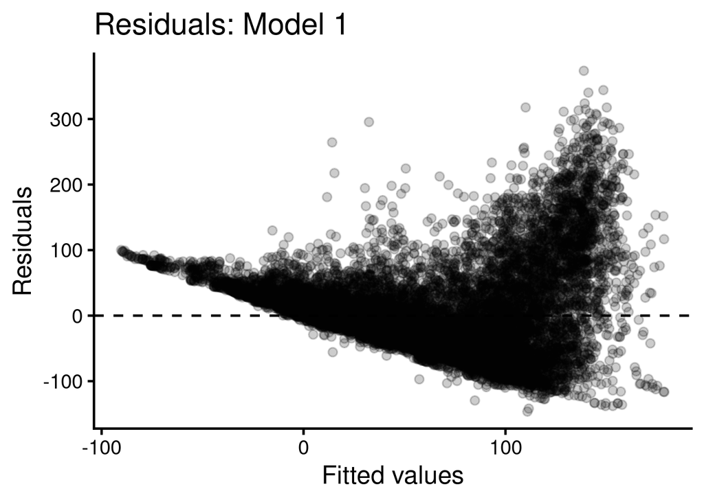

```r
ggplot(aug_m1, aes(x = .fitted, y = .resid)) +
  geom_point(alpha = 0.2) +
  geom_hline(yintercept = 0, linetype = "dashed") +
  theme_classic(base_size = 18) +
  labs(
    x = "Fitted values",
    y = "Residuals",
    title = "Residuals: Model 1"
  )
```

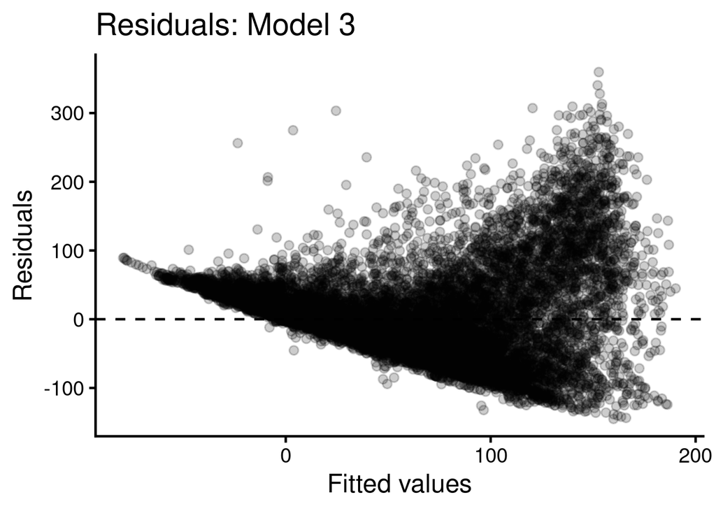

```r
ggplot(aug_m3, aes(x = .fitted, y = .resid)) +
  geom_point(alpha = 0.2) +
  geom_hline(yintercept = 0, linetype = "dashed") +
  theme_classic(base_size = 18) +
  labs(
    x = "Fitted values",
    y = "Residuals",
    title = "Residuals: Model 3"
  )
```

> Do the residual plots suggest any problems (curvature, changing variance, outliers)? Which model looks more appropriate? The residual plots for Model 1 and Model 3 show variance at high fitted values.

## 14) Make a model selection decision

Choose the model you think is best supported by the evidence.

Fill in:

> My preferred model is `Model 3`

> I based this decision on: - `Highest R^2` - `Lowest RMSE` - `Visual fit seems better`

**Prompt (5–7 sentences):** Explain why you chose this model. Use at least two quantitative criteria (such as R-squared, RMSE, or sigma) and one visual criterion (such as the residual plot or scatterplot). Also explain why a different model was less convincing.

> *I chose Model 3 as the best model because it consistently outperformed the others models. Quantitatively, Model 3 achieved the highest R^2, meaning it explains approximately 40.4% of the variability in latent heat flux. It also yielded the lowest RMSE of 61.63, indicating more accurate predictions. Visually, while the residual plots for all models show a “fan” shape, Model 3’s residuals are more densely concentrated near the horizontal, suggesting a better overall fit to the data. In comparison, Model 2 was significantly less convincing; it explained only about 8.3% of the variance and had a much higher RMSE of 76.48.*

# Part II — Train/Test Splits and Cross-Validation

In this section you will extend model selection toward **prediction**.

You will:

- choose **two new predictors** (not `ta` or `swc`) to explain `le`
- hold out a **test set**
- use **4-fold cross-validation on training data**
- choose between **two candidate models**
- refit the chosen model on all training data
- evaluate it once on the held-out test data

The key idea is:

> Use training data to build models, validation folds to choose among them, and test data only once for final evaluation.

## 15) Choose two new predictors for `le`

Choose **two predictors that are NOT `ta` or `swc`**.

Possible examples depend on your file, but might include things like: - `vpd` - `rg` - `fc` - `gpp` - `h` - `rh`

```r
response_var <- "le"
pred1 <- "fc"
pred2 <- "rh"

# CHECK: do these exist?
c(response_var, pred1, pred2) %in% names(df)
```

```
## [1] TRUE TRUE TRUE
```

> Why did you choose these two predictors? I think they may be related because le represents energy exchange (could be related to CO2) and water vapor.

## 16) Create a clean modeling dataset

Keep only complete cases for the response and the two predictors.

```r
df_pred <- df %>%
  select(response_var, pred1, pred2) %>%
  drop_na()

glimpse(df_pred)
```

```
## Rows: 15,851
## Columns: 3
## $ le <dbl> -2.975490, -1.814240, -5.101540, -4.854642, -2.419090, -10.083700, …
## $ fc <dbl> 1.44447000, 1.00187000, 1.76657000, 0.46398500, 0.82432900, 0.64415…
## $ rh <dbl> 56.3240, 56.0741, 56.0960, 56.2822, 57.5869, 60.5177, 27.8732, 23.6…
```

> How many observations remain after removing missing values? 15851

## 17) Shuffle rows and create a train/test split

Use 20% of the data as a final **test set**.

```r
set.seed(12)

df_shuf <- df_pred %>%
  slice_sample(prop = 1)

n_total <- nrow(df_shuf)
n_test <- round(0.20 * n_total)

test_data <- df_shuf %>% slice(1:n_test)
train_data <- df_shuf %>% slice((n_test + 1):n_total)

tibble(
  dataset = c("train", "test"),
  n = c(nrow(train_data), nrow(test_data))
)
```

| dataset | n |
| --- | --- |
| train | 12681 |
| test | 3170 |

> Why do we keep the test set separate from model selection? We keep the test set separate to get an unbiased evaluation of the final model’s performance on “unseen” data.

## 18) Define two candidate models

Use:

- **Model 1:** `le ~ pred1`
- **Model 2:** `le ~ pred1 + pred2`

Write them out in words below:

> Model 1: `Latent heat turbulent flux is modeled as a function of Carbon Dioxide (CO2) turbulent flux.`

> Model 2: `Latent heat turbulent flux is modeled as a function of both Carbon Dioxide (CO2) turbulent flux and Relative humidity.`

## 19) Create 4 folds on the training data

```r
set.seed(12)

train_folds <- train_data %>%
  mutate(fold = rep(1:4, length.out = n()))

train_folds %>% count(fold)
```

| fold | n |
| --- | --- |
| 1 | 3171 |
| 2 | 3170 |
| 3 | 3170 |
| 4 | 3170 |

> Why do we create folds only on the training data, and not using the test data? To simulate the process of seeing “new” data while still preserving the final test set for final evaluation. This prevents data leakage.

## 20) Run 4-fold cross-validation

For each fold:

- train on 3 folds
- validate on 1 held-out fold
- compute RMSE

```r
cv_results <- map_dfr(1:4, function(k) {

  cv_train <- train_folds %>% filter(fold != k)
  cv_valid <- train_folds %>% filter(fold == k)

  m1 <- lm(cv_train[[response_var]] ~ cv_train[[pred1]], data = cv_train)
  m2 <- lm(cv_train[[response_var]] ~ cv_train[[pred1]] + cv_train[[pred2]], data = cv_train)

  tibble(
    fold = k,
    model = c("m1", "m2"),
    rmse = c(
      sqrt(mean((cv_valid[[response_var]] - predict(m1, newdata = cv_valid))^2)),
      sqrt(mean((cv_valid[[response_var]] - predict(m2, newdata = cv_valid))^2))
    )
  )
})

cv_results
```

| fold | model | rmse |
| --- | --- | --- |
| 1 | m1 | 97.82963 |
| 1 | m2 | 98.04533 |
| 2 | m1 | 95.91706 |
| 2 | m2 | 96.05756 |
| 3 | m1 | 98.57913 |
| 3 | m2 | 98.80256 |
| 4 | m1 | 97.38180 |
| 4 | m2 | 97.46037 |

## 21) Summarize cross-validation performance

Compute the mean and SD of RMSE across folds.

```r
cv_summary <- cv_results %>%
  group_by(model) %>%
  summarise(
    mean_rmse = mean(rmse),
    sd_rmse = sd(rmse),
    .groups = "drop"
  )

cv_summary
```

| model | mean_rmse | sd_rmse |
| --- | --- | --- |
| m1 | 97.42691 | 1.121231 |
| m2 | 97.59145 | 1.160862 |

> Which model has the lower average validation RMSE?  
> What does the SD across folds tell you? Model 1 has a lower mean RMSE. SD tells us how much the model performance varies depending on which subset of data it is trained on.

## 22) Visualize fold-by-fold validation RMSE

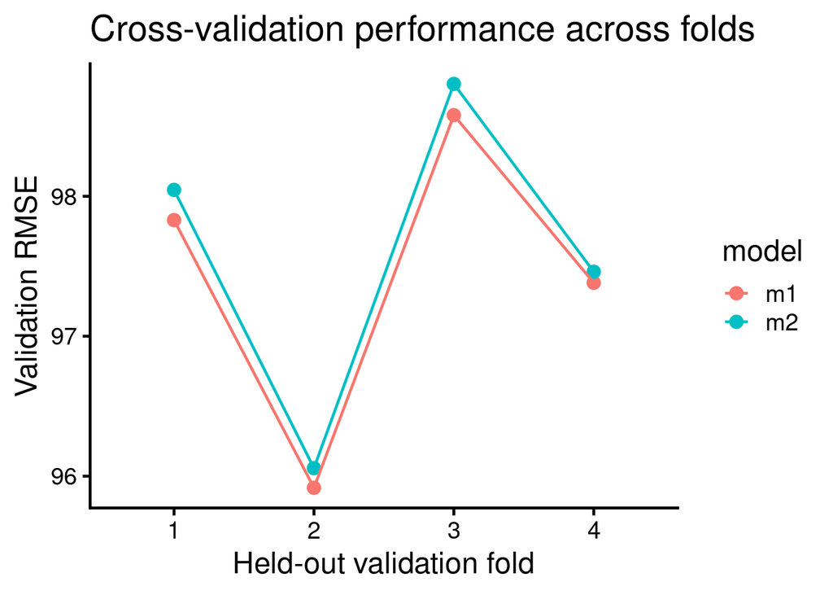

```r
ggplot(cv_results, aes(x = factor(fold), y = rmse, color = model, group = model)) +
  geom_point(size = 3) +
  geom_line() +
  theme_classic(base_size = 18) +
  labs(
    x = "Held-out validation fold",
    y = "Validation RMSE",
    title = "Cross-validation performance across folds"
  )
```

> Does one model win consistently across folds, or only sometimes? Model 1 always wins.

## 23) Choose your preferred model

Fill in:

> My selected model is: `Model 1`

> I chose it because: `is consistent with a low mean RMSE and low SD RMSE`

## 24) Refit the chosen model on all training data

Use all of `train_data` now that you have selected the model.

```r
final_model <- lm(train_data, data = train_data)

tidy(final_model)
```

| term | estimate | std.error | statistic | p.value |
| --- | --- | --- | --- | --- |
| (Intercept) | 81.2226772 | 1.7589902 | 46.17574 | 0.000000e+00 |
| fc | -6.4695216 | 0.0625982 | -103.34997 | 0.000000e+00 |
| rh | -0.3363937 | 0.0314485 | -10.69665 | 1.370037e-26 |

## 25) Evaluate the final model on the test set

Use `predict()` and compute test RMSE.

```r
test_pred <- predict(final_model, newdata = test_data)

test_rmse <- sqrt(mean((test_data[[response_var]] - test_pred)^2))

test_rmse
```

```
## [1] 56.16054
```

> How does the test RMSE compare with the cross-validation RMSE? The test RMSE is significantly lower than the average cross-validation RMSE. This suggests the model generalized very well to this specific test set.

## 26) Final interpretation

Answer in **5–7 sentences**:

- Why did you not use the test data during model selection?
- How did cross-validation help you choose between models?
- Did the chosen model generalize well to test data?
- What would it mean if test RMSE were much worse than validation RMSE?

# Submission

- Knit your `.Rmd` to HTML.
- Commit and push both the `.Rmd` and knitted `.html` to your GitHub repo.
- Submit the GitHub repository link on Canvas.